# Fraud Detection Analytics Phase 2 Predictive Analytics

**Capstone Project: Fraud Detection Analytics**

This capstone project has a lifecycle analytics process with two phases in two separated notebooks:

**❏ Phase 1: Exploratory Data Analysis (first notebook: Fraud Detection Analytics Part 1 Exploratory Data Analysis.ipynb)**

- Data Input: carclaims.csv (raw data: https://www.kaggle.com/code/rashmiek99/vehicle-insurance-fraud-detection)
- Data Output: df_cleaned (cleaned for modeling in Phase 2)

**❏ Phase 2: Predictive Analytics (second notebook: Fraud Detection Analytics Part 2 Predictive Analytics.ipynb)**

- Data Input: df_cleaned (cleaned from Phase 1)
- Model Output: Predictive Analytics and Fraud Detection Insights

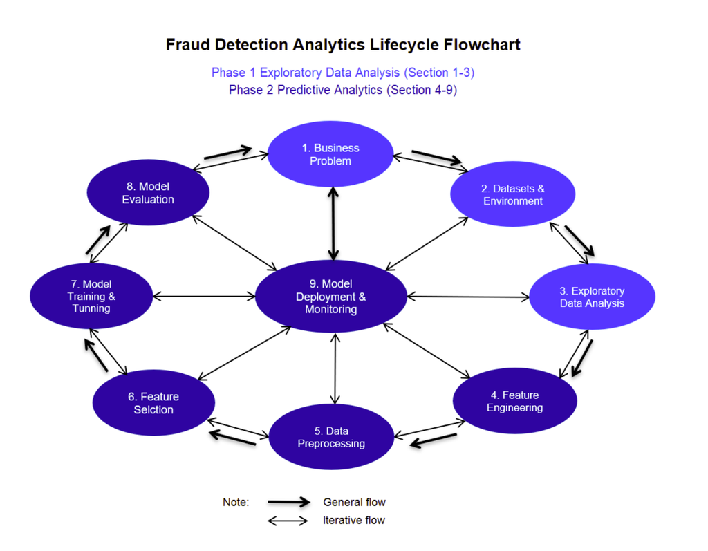

**CONTENT**

**❏ Phase 1: Exploratory Data Analysis**

### Section 1. Problem Statement

### Section 2. Datasets & Environment

### Section 3. Exploratory Data Analysis (EDA)

#### 3.1. Initial Exploratory Data Review

#### 3.2. Individual Variable Review and Visualization

##### 3.2.1. Target Variable / Label

##### 3.2.2. Continuous Variables

##### 3.2.3. Categorical Variables

#### 3.3 Data Cleaning

Based on the data review:

- 3.3.1. Data Fields Deleting:
  - PolicyNumber is not meaningful so dropped from this analysis
  - Age is dropped due to AgeOfPolicyholder capturing better data quality
  - Deductible is dropped due to very poor data quality
- 3.3.2. Imputation: There are a few columns with value of 0 which was replaced by the most frequent values

### Exploratory Data Analysis Summary

#### 1. Overall Fraud Rate: The target variable / label shows only 6% of Claims are detected as Fraud which dataset is extremely imbalanced

- Fraud cases: 923 (5.99%)
- Non-fraud cases: 14,497 (94.01%) ➡️ Fraud is relatively rare, but patterns emerge across certain categories.

#### 3. Vehicle & Policy Features

- Vehicle Category: Utility (11.25%) → highest fraud risk; Sedan (8.22%) → moderate risk; Sport (1.57%) → lowest risk.
- Policy Type: Sport-Collision (13.79%), Utility-All Perils (12.06%), Sedan-All Perils (10.05%) → high risk; Sedan-Liability (0.72%) → very low risk.
- Base Policy: All Perils (10.16%) shows higher fraud than Collision (7.29%) or Liability (0.72%).
- Vehicle Price: Fraud is higher in low (<20k, 9.4%) and high (>69k, 8.7%) price ranges.

#### 5. Claim & Accident Details

- Fault: Policy Holder at fault → 7.89% fraud; Third Party at fault → 0.88%.
- Accident Area: Rural (8.32%) vs. Urban (5.72%).
- Police Report Filed: Fraud lower when reports are filed (3.74% vs. 6.05%).
- Witness Present: Fraud lower when witnesses are present (3.45% vs. 6.0%). ➡️ Lack of external verification (no police report, no witness) correlates with higher fraud.

#### Key Insights

- Fraud prevalence: Overall fraud is rare (~6%), but concentrated in specific demographics and policy/vehicle types.
- Demographics: Younger drivers (18–25 years, 13–15% fraud), males (6.29%), and widowed policyholders (8.57%) show elevated risk compared to other groups.
- Vehicle Category: Utility vehicles (11.25%) are riskiest, while Sport vehicles (1.57%) are lowest.
- Policy Type: Complex policies such as Sport - Collision (13.79%), Utility - All Perils (12.06%), and Sedan - All Perils (10.05%) stand out as high-risk.
- Seasonality: Fraud risk spikes in March (7.5%) and August (7.45%), with the lowest in November (3.83%).
- Location & Evidence: Fraud is more common in rural areas (8.32%) and when no police report or witness is filed, suggesting external verification reduces fraud.
- High-risk combinations: Profiles such as young male + Utility vehicle + All Perils policy represent strong predictive signals for modeling.

**❏ Phase 2: Predictive Analytics**

### Section 4.Feature Engineering

#### 4.1. Grouping by similar fraud risk/rate

#### 4.2. Creating indicator for very high or low fraud risk/rate

#### Feature Engineering Summary:

- 4 raw data fields were created by regrouping similar fraud risk
- 5 indicators were created for high/low fraud risk
- Benefits: - Stability (avoids inflated fraud % from tiny sample sizes), - Interpretability (easier to explain risk by broad categories) - Model performance (reduces dimensionality and prevents overfitting to rare categories)

### Section 5. Data Preprocessing

#### 5.2. Splitting into train and test sets for modeling

#### 5.3. Upsampling to address the imbalanced data

- The dataset is extremely imbalanced so the model performance is poor. To address the imbalanced target data concern, The following two methods were applied and the upscale one was better so included in this analytics:
  1. Upscale the Minority Class (where FraudFound ==1) -- this was included in this notebook
  2. Downsample the Majority Class (where FraudFound ==0) --> this was tested but not included in this notebook due to space concern

### Section 6. Feature Selection

- Feature Importance Ranking
- Correlation Review

### Section 7. Modeling & Tunning

- Modeling on 5-fold CV, model testing and tuning to ensure generalizability
  - Logistic Regression
  - Decision Tree
  - Random Forest
  - Gradient Boosting
  - XGBoost
  - Deep Learning / Deep Neural Networks
- Hyperparameter tuning and grid search to improve model performance

### Section 8. Model Evaluation

- Performance Metrices (Accuracy, Precision, Recall, F1, ROC-AUC)
- Explainability

### Key Fraud Detection Insights

**1. Recall is King in Fraud Detection**

**2. Precision Trade-off**

**3. ROC-AUC Analysis**

- XGBoost (0.824) and Gradient Boosting & Random Forest (0.812) lead in ROC-AUC, meaning they rank transactions well by fraud likelihood.
- DNN’s ROC-AUC (0.803) is slightly lower, so probability calibration may need improvement for threshold tuning.

### A Few Recommended Future Work

1. Data Expansion: incorporating more relevant data sources
2. Investigation: outliers and potential sampling biases
3. Multicollinearity Review: Use techniques like PCA or VIF to manage highly correlated features
4. Feature Engineering: Create meaningful features, composite features, and/or interaction terms. e.g.: Consider combining variables into interaction terms and review if the joint effect seems significant or not.

**❏ Phase 2: Predictive Analytics (second notebook: Fraud Detection Analytics Phase 2 Predictive Analytics.ipynb)**

- Import Libraries

```python
import numpy as np
import pandas as pd

import os
for dirname, _, filenames in os.walk('/kaggle/input'):
    for filename in filenames:
        print(os.path.join(dirname, filename))

import matplotlib.pyplot as plt
import seaborn as sns

from sklearn.preprocessing import LabelEncoder, StandardScaler
from sklearn.model_selection import train_test_split
from sklearn.linear_model import LogisticRegression
from sklearn.ensemble import RandomForestClassifier
from sklearn.metrics import f1_score, accuracy_score, confusion_matrix,roc_auc_score
from sklearn.utils import resample
import warnings
warnings.filterwarnings("ignore")
```

```python
# Utility Functions
def eds(df,head_size = 5, tail_size = 5, show_info = True):
    '''print df summary statistics to screen'''
    print_heading("Data Review Summary")
    print_heading("Data Table: Row x Column")                            # Review # of Row x By of Column
    print("Number of Row / Records:",df.shape[0])
    print("Number of Column / Features / Data Fields:",df.shape[1])

    print_heading("Review Top 5 Rows:")                                  # Review Top 5 Rows
    display(df.head(head_size))
    # print_heading("Review Bottom 5 Rows:")
    # display(df.tail(tail_size))

    print_heading("Review Descriptive Statistics:")                      # Review Descriptive Statistics
    display(df.describe().transpose())
    # df_hc['col'].value_counts(normalize = True)

    if show_info:

        print_heading("Review Data Table: Column Names and Data Types")  # Review Column Names and Data Types
        display(df.info())

        # print_heading("Data Table: Most frequent value")                 # Review Column Names and Data Types
        # display(df[col].mode())

        print_heading("Review Unique Values by Column:")                 # Review Unique Values by Column
        display(df.nunique())

        print_heading("Review Duplicated Row(s):")                       # Review Duplicated Values by Column
        display(df[df.duplicated()].shape[0])

        # gapminder.continent.unique()
        print_heading("Review Total Missing Values (1) isnull")             # Review isnull Missing Values By Column
        display(df.isnull().sum())
        # Percentage of missing values
        print_heading("Review % isnull Missing Values by Column:")       # Review Missing Values By Column
        isnull_val = df.isnull().sum()
        isnull_val_percent = 100 * df.isnull().sum() / len(df)
         # Make a table with the results
        isnull_val_table = pd.concat([isnull_val, isnull_val_percent], axis=1)
        # Rename the columns
        isnull_val_table_ren_columns = isnull_val_table.rename(
        columns = {0 : 'isnullMissing Values', 1 : '%isnull of Total Values'})
        # Sort the table by percentage of missing descending
        isnull_val_table_ren_columns = isnull_val_table_ren_columns[
            isnull_val_table_ren_columns.iloc[:,1] != 0].sort_values('%isnull of Total Values', ascending=False).round(1)
        # Print some summary information
        print ("Your selected dataframe has " + str(df.shape[1]) + " columns.\n"
            "There are " + str(isnull_val_table_ren_columns.shape[0]) +
              " columns that have missing values.")
        # Return the dataframe with missing information
        #return isnull_val_table_ren_columns

        print_heading("Review isna Total Missing Values (2) isna:")               # Review isna Missing Values By Column
        display(df.isna().sum())
        # Percentage of missing values
        print_heading("Review % isna Missing Values by Column:")         # Review Missing Values By Column
        isna_val = df.isna().sum()
        isna_val_percent = 100 * df.isna().sum() / len(df)


        isna_val_table = pd.concat([isna_val, isna_val_percent], axis=1)
        # Rename the columns
        isna_val_table_ren_columns = isna_val_table.rename(
        columns = {0 : 'isnaMissing Values', 1 : '%isna of Total Values'})
        # Sort the table by percentage of missing descending
        isna_val_table_ren_columns = isna_val_table_ren_columns[
            isna_val_table_ren_columns.iloc[:,1] != 0].sort_values('%isna of Total Values', ascending=False).round(1)
        # Print some summary information
        print ("Your selected dataframe has " + str(df.shape[1]) + " columns.\n"
            "There are " + str(isna_val_table_ren_columns.shape[0]) +
              " columns that have missing values.")
        # Return the dataframe with missing information
        #return isna_val_table_ren_columns

        # df.isna().sum().sort_values(ascending=False).plot(kind = 'bar')    # df.isna().sum()
        # plt.show()

def print_heading(heading):
    print("\n" + "="*50)
    print(heading)
    print("="*50)

# Function to print brief info for the given DataFrame object and column
def print_col_info(df, col):
    print(f"\nColumn: Review {col}")
    print(df[col].value_counts(normalize=True, sort=True, ascending=False))
    print(f"Unique values: {df[col].nunique()}\n")
    print(f"Most frequent: {df[col].mode()}\n")
    print(f"Missing values: {df[col].isnull().sum()}\n")
```

### Section 4.Feature Engineering

#### 4.1. Grouping by similar fraud risk/rate

#### 4.2. Creating indicator for very high or low fraud risk/rate

#### Feature Engineering Summary

- Import Cleaned Data from Phase 1

```python
%pwd
```

```
'C:\\Users\\Mei\\BerkeleyPE\\AIandML\\Capstone Project\\CapstoneExamples'
```

```python
df_cleaned = pd.read_csv('df_cleaned.csv',index_col=0)
df_cleaned.shape
```

```
(15420, 30)
```

```python
df_cleaned.info()
```

```
<class 'pandas.core.frame.DataFrame'>
Index: 15420 entries, 0 to 15419
Data columns (total 30 columns):
 #   Column                Non-Null Count  Dtype
---  ------                --------------  -----
 0   Month                 15420 non-null  object
 1   WeekOfMonth           15420 non-null  int64
 2   DayOfWeek             15420 non-null  object
 3   Make                  15420 non-null  object
 4   AccidentArea          15420 non-null  object
 5   DayOfWeekClaimed      15420 non-null  object
 6   MonthClaimed          15420 non-null  object
 7   WeekOfMonthClaimed    15420 non-null  int64
 8   Sex                   15420 non-null  object
 9   MaritalStatus         15420 non-null  object
```

[output cut: 22 more lines]

```python
cols_to_convert = ['WeekOfMonth', 'WeekOfMonthClaimed', 'RepNumber', 'DriverRating','Year']
df_cleaned[cols_to_convert] = df_cleaned[cols_to_convert].astype('object')
df_cleaned.info()
```

```
<class 'pandas.core.frame.DataFrame'>
Index: 15420 entries, 0 to 15419
Data columns (total 30 columns):
 #   Column                Non-Null Count  Dtype
---  ------                --------------  -----
 0   Month                 15420 non-null  object
 1   WeekOfMonth           15420 non-null  object
 2   DayOfWeek             15420 non-null  object
 3   Make                  15420 non-null  object
 4   AccidentArea          15420 non-null  object
 5   DayOfWeekClaimed      15420 non-null  object
 6   MonthClaimed          15420 non-null  object
 7   WeekOfMonthClaimed    15420 non-null  object
 8   Sex                   15420 non-null  object
 9   MaritalStatus         15420 non-null  object
```

[output cut: 22 more lines]

- Review Fraud Count and % Distribution by Each Feature

```python
cat_col = df_cleaned.select_dtypes(include=['object']).columns.tolist()

for i in cat_col:
    # Raw counts
    counts = df_cleaned[i].value_counts(dropna=False)
    dist = df_cleaned[i].value_counts(normalize=True, dropna=False) * 100

    # FraudFound counts and percentages per category
    fraud_counts = df_cleaned.groupby(i)["FraudFound"].sum()   # assumes FraudFound is 0/1
    fraud_percent = df_cleaned.groupby(i)["FraudFound"].mean() * 100

    # Align with sorted categories
    dist_sorted = dist.sort_index()
    counts_sorted = counts.loc[dist_sorted.index]
    fraud_counts_sorted = fraud_counts.loc[dist_sorted.index]
    fraud_percent_sorted = fraud_percent.loc[dist_sorted.index]

    # Cumulative %
    cum_dist = dist_sorted.cumsum()

    # Build DataFrame
    dist_df = pd.DataFrame({
        'Count': counts_sorted,
        'Percentage': dist_sorted,
        'Cumulative %': cum_dist,
        'Fraud Count': fraud_counts_sorted,
        'Fraud %': fraud_percent_sorted
    })

    print(f'\n=== {i} Distribution ===')
    print(dist_df, '\n')
```

```
=== Month Distribution ===
       Count  Percentage  Cumulative %  Fraud Count   Fraud %
Month
Apr     1280    8.300908      8.300908           80  6.250000
Aug     1127    7.308690     15.609598           84  7.453416
Dec     1285    8.333333     23.942931           62  4.824903
Feb     1266    8.210117     32.153048           82  6.477093
Jan     1411    9.150454     41.303502           87  6.165840
Jul     1257    8.151751     49.455253           60  4.773270
Jun     1321    8.566796     58.022049           80  6.056018
Mar     1360    8.819715     66.841764          102  7.500000
May     1367    8.865110     75.706874           94  6.876372
Nov     1201    7.788586     83.495460           46  3.830142
Oct     1305    8.463035     91.958495           70  5.363985
Sep     1240    8.041505    100.000000           76  6.129032


=== WeekOfMonth Distribution ===
             Count  Percentage  Cumulative %  Fraud Count   Fraud %
WeekOfMonth
1             3187   20.667964     20.667964          200  6.275494
2             3558   23.073930     43.741894          225  6.323777
3             3640   23.605707     67.347601          215  5.906593
4             3398   22.036316     89.383917          192  5.650383
5             1637   10.616083    100.000000           91  5.558949


=== DayOfWeek Distribution ===
           Count  Percentage  Cumulative %  Fraud Count   Fraud %
DayOfWeek
Friday      2445   15.856031     15.856031          154  6.298569
Monday      2616   16.964981     32.821012          160  6.116208
Saturday    1982   12.853437     45.674449          132  6.659939
Sunday      1745   11.316472     56.990921          122  6.991404
Thursday    2173   14.092088     71.083009          120  5.522319
Tuesday     2300   14.915694     85.998703          120  5.217391
Wednesday   2159   14.001297    100.000000          115  5.326540


=== Make Distribution ===
```

[output cut: 259 more lines]

```

=== Year Distribution ===
      Count  Percentage  Cumulative %  Fraud Count   Fraud %
Year
1994   6142   39.831388     39.831388          409  6.659069
1995   5195   33.690013     73.521401          301  5.794033
1996   4083   26.478599    100.000000          213  5.216752


=== BasePolicy Distribution ===
            Count  Percentage  Cumulative %  Fraud Count    Fraud %
BasePolicy
All Perils   4449   28.852140     28.852140          452  10.159586
Collision    5962   38.664073     67.516213          435   7.296209
Liability    5009   32.483787    100.000000           36   0.718706
```

#### 4.1. Grouping by similar fraud risk/rate

```python
# --- AgeOfPolicyHolder grouping ---

def age_group(x):
    if x in ['16 to 17', '18 to 20','21 to 25']:
        return "16-25"
    elif x in ['26 to 30','31 to 35','36 to 40']:
        return "26-40"
    # elif x in ['41 to 50','51 to 65']:
    #     return "41-65"
    else:
        return "65+"

df_cleaned["Age_grp"] = df_cleaned["AgeOfPolicyHolder"].apply(age_group)

highfraud_brands = ["BMW", "Mercury", "BMW","Mercury","Ford","Saab","Saturn","Accura","Mecedes"]
df_cleaned["Make_grp"] = df_cleaned["Make"].apply(
    lambda x: "HighFraud" if x in highfraud_brands else
              "ModerateFraud" if x in ["Honda", "Toyota", "Chevrolet", "Pontiac", "Mazda"] else
              "LowFraud"
)
# --- PolicyType grouping ---
# def simplify_policy(x):
#     if "All Perils" in x:
#         return "All Perils"
#     elif "Collision" in x:
#         return "Collision"
#     elif "Liability" in x:
#         return "Liability"
#     else:
#         return "Other"

# df1["Policy_Cov_grp"] = df1["PolicyType"].apply(simplify_policy)
# df1["PolicyVehicle_grp"] = df1["PolicyType"].str.split(" - ").str[0]

# --- VehiclePrice grouping ---
def price_group(x):
    if "less than 20,000" in x:
        return "Low (20k-)"
    elif "more than 69,000" in x:
        return "High [69k+)"
    else:
        return "Mid [20–69k)"

df_cleaned["VehiclePrice_grp"] = df_cleaned["VehiclePrice"].apply(price_group)

# --- AgeOfVehicle grouping ---
def num_car_group(x):
    if x in ["1 vehicle","2 vehicles"]:
        return "1-2car"
    else:
        return "3+cars"

# --- AgeOfVehicle grouping ---
def age_group(x):
    if x in ["new","2 years","3 years","4 years"]:
        return "0-4yr"
    else:
        return x

df_cleaned["VehicleAge_grp"] = df_cleaned["AgeOfVehicle"].apply(age_group)

print("Grouping complete: 4 New grouped features added.")
```

```
Grouping complete: 4 New grouped features added.
```

#### 4.2. Creating indicator for very high or low fraud risk/rate

```python
# --- Days:Policy-Accident indicator ---
def accident_days_group(x):
    # if x in ["none"]:
    #     return "None"
    if x in ["none","1 to 7", "8 to 15", "15 to 30"]:
        return "0"
    else:
        return "1"

df_cleaned["PolicyAccidentDays30+_ind"] = df_cleaned["Days:Policy-Accident"].apply(accident_days_group)

# --- Days:Policy-Claim grouping ---
def claim_days_ind(x):
    if x in ["none", "8 to 15", "15 to 30"]:
        return "0"
    else:
        return "1"

df_cleaned["PolicyClaimDays30+_ind"] = df_cleaned["Days:Policy-Claim"].apply(claim_days_ind)

def pastclaimfree_ind(x):
    if x in ["none"]:
        return "1"
    else:
        return "0"
df_cleaned["Pastclaimfree_ind"] = df_cleaned["PastNumberOfClaims"].apply(pastclaimfree_ind)

def addresschange4yr_ind(x):
    if x in ["4 to 8 years","no change"]:
        return "1"
    else:
        return "0"
df_cleaned["AddressChange4yr+_Ind"] = df_cleaned["AddressChange-Claim"].apply(addresschange4yr_ind)

def NumSuppliments0to2_ind(x):
    if x in ["none", "1 to 2"]:
        return "1"
    else:
        return "0"

df_cleaned['NumSuppliments0to2_ind'] = df_cleaned['NumberOfSuppliments'].apply(NumSuppliments0to2_ind)

print("Create Indicator complete: 5 New dummy features added.")
```

```
Create Indicator complete: 5 New dummy features added.
```

- Individual Feature Profiling and Visualization

```python
df2 = df_cleaned.copy().drop(['AgeOfPolicyHolder','VehiclePrice','Make','AgeOfVehicle','Days:Policy-Accident','Days:Policy-Claim',
                              'PastNumberOfClaims','AddressChange-Claim','NumberOfSuppliments'],axis=1)
df_cleaned.shape, df2.shape
```

```
((15420, 39), (15420, 30))
```

```python
df2.columns
```

```
Index(['Month', 'WeekOfMonth', 'DayOfWeek', 'AccidentArea', 'DayOfWeekClaimed',
       'MonthClaimed', 'WeekOfMonthClaimed', 'Sex', 'MaritalStatus', 'Fault',
       'PolicyType', 'VehicleCategory', 'RepNumber', 'DriverRating',
       'PoliceReportFiled', 'WitnessPresent', 'AgentType', 'NumberOfCars',
       'Year', 'BasePolicy', 'FraudFound', 'Age_grp', 'Make_grp',
       'VehiclePrice_grp', 'VehicleAge_grp', 'PolicyAccidentDays30+_ind',
       'PolicyClaimDays30+_ind', 'Pastclaimfree_ind', 'AddressChange4yr+_Ind',
       'NumSuppliments0to2_ind'],
      dtype='object')
```

#### Feature Engineering Summary:

- 4 raw data fields were regrouped based on similar fraud risk for benefits
- 5 indicators were created for high/low fraud risk
- Benefits: - Stability (avoids inflated fraud % from tiny sample sizes), - Interpretability (easier to explain risk by broad categories) - Model performance (reduces dimensionality and prevents overfitting to rare categories)

### Section 5. Data Preprocessing

#### 5.2. Splitting into train and test sets for modeling

#### 5.3. Upsampling to address the imbalanced data

- The dataset is extremely imbalanced so the model performance is poor. To address the imbalanced target data concern, The following two methods were applied and the upscale one was better so included in this analytics:
  1. Upscale the Minority Class (where FraudFound ==1) -- this was included in this notebook
  2. Downsample the Majority Class (where FraudFound ==0) --> this was tested but not included in this notebook due to space concern

### 5.1. Encoding

#### 5.1.1. Data encoding for modeling

```python
# One-hot encode categorical variables
cat_col = df2.select_dtypes(include=['object']).columns.tolist()
df_encoded = pd.get_dummies(df2, columns=cat_col, drop_first=True)
df_encoded.shape
```

```
(15420, 103)
```

#### 5.1.2. Quick Correlation Review

- Top 30 features highly correlated with target / label

```python
import pandas as pd

# Create correlation matrix
corr_matrix = df_encoded.corr()

# Extract correlations with target only
target_corr = corr_matrix['FraudFound']#.drop('FraudFound')

# Sort by strength of relationship
top_corr = target_corr.abs().sort_values(ascending=False)

# print(top_corr.head(20).to_dict(orient='records'))  # Top 10 correlated features with target
# print(list(top_corr.head(20).items()))
data=list(top_corr.head(30).items())
df = pd.DataFrame(data, columns=['Variable', 'Value'])

for i, (var, val) in enumerate(zip(df['Variable'], df['Value']), start=1):
     print(f"{i}. {var}: {val}")
    # print('"'f"{var}"'"'',')
```

```
1. FraudFound: 1.0
2. BasePolicy_Liability: 0.15400657005802473
3. PolicyType_Sedan - Liability: 0.15341348258853463
4. VehicleCategory_Sport: 0.13590259723957615
5. Fault_Third Party: 0.13138922286009166
6. VehiclePrice_grp_Mid [20–69k): 0.06485392176689103
7. AddressChange4yr+_Ind_1: 0.05941205745113159
8. PolicyType_Sport - Collision: 0.05000960563450243
9. Pastclaimfree_ind_1: 0.047680424669586136
10. BasePolicy_Collision: 0.04386014124013901
11. VehiclePrice_grp_Low (20k-): 0.03978656534452585
12. PolicyType_Utility - All Perils: 0.03844085244602963
13. VehicleCategory_Utility: 0.035815364545068354
14. NumSuppliments0to2_ind_1: 0.033878582783686176
15. AccidentArea_Urban: 0.03349946347169286
16. MonthClaimed_Nov: 0.0305800116880635
17. Sex_Male: 0.029953323068743633
18. PolicyType_Sedan - Collision: 0.0283017884391587
19. Make_grp_ModerateFraud: 0.02730115039833295
20. Month_Nov: 0.026408750014684276
21. MonthClaimed_Aug: 0.025849070170264547
22. Make_grp_LowFraud: 0.02490008634857571
23. Age_grp_65+: 0.023126052608421883
24. AgentType_Internal: 0.022978203971163205
25. MonthClaimed_Dec: 0.0204247978763555
26. VehicleAge_grp_more than 7: 0.020172029413872694
27. Month_Mar: 0.019852891028809657
28. PolicyAccidentDays30+_ind_1: 0.019842145945621715
29. Year_1996: 0.019453616759029797
30. MonthClaimed_Jul: 0.017514092697471787
```

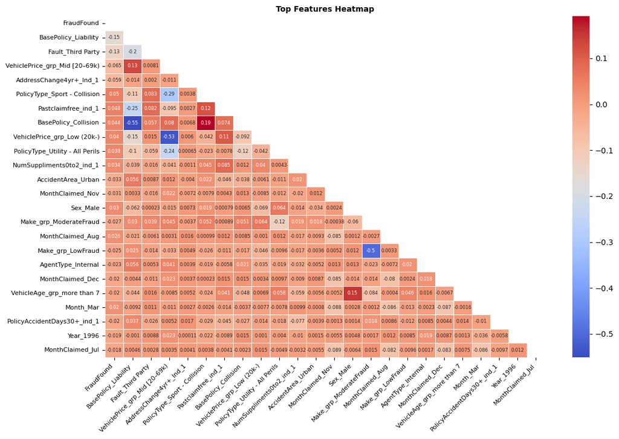

```python
# "BasePolicy_Liability" vs "VehicleCategory_Sport" vs "BasePolicy_Collision"--> drop "VehicleCategory_Sport" "BasePolicy_Collision"
# VehiclePrice_grp_Low (<20k) vs VehiclePrice_grp_Mid (20–69k) --> drop VehiclePrice_grp_Low (<20k)
# MonthClaimed_Nov vs Month_Nov --> drop Month_Nov
# Make_grp_ModerateFraud vs Make_grp_LowFraud --> drop Make_grp_LowFraud
# Age_grp_65+ vs VehicleAge_grp_more than 7 --> drop VehicleAge_grp_more than 7
# MonthClaimed_Aug vs Month_Aug --> drop Month_Aug
# Month_Mar vs MonthClaimed_Mar --> drop MonthClaimed_Mar
# PolicyAccidentDays30+_ind_1 vs PolicyClaimDays30+_ind_1 --> drop PolicyClaimDays30+_ind_1

df_topcorr = df_encoded[["FraudFound",
"BasePolicy_Liability",
# "PolicyType_Sedan - Liability",
# "VehicleCategory_Sport",
"Fault_Third Party",
"VehiclePrice_grp_Mid [20–69k)",
"AddressChange4yr+_Ind_1",
"PolicyType_Sport - Collision",
"Pastclaimfree_ind_1",
"BasePolicy_Collision",
"VehiclePrice_grp_Low (20k-)",
"PolicyType_Utility - All Perils",
# "VehicleCategory_Utility",
"NumSuppliments0to2_ind_1",
"AccidentArea_Urban",
"MonthClaimed_Nov",
"Sex_Male",
# "PolicyType_Sedan - Collision",
"Make_grp_ModerateFraud",
# "Month_Nov",
"MonthClaimed_Aug",
"Make_grp_LowFraud",
# "Age_grp_65+",
"AgentType_Internal",
"MonthClaimed_Dec",
"VehicleAge_grp_more than 7",
"Month_Mar",
"PolicyAccidentDays30+_ind_1",
"Year_1996",
"MonthClaimed_Jul"]]


plt.figure(figsize=(12, 8))
mask = np.triu(np.ones_like(df_topcorr.corr(), dtype=bool))

sns.heatmap(
    df_topcorr.corr(),
    annot=True,
    cmap='coolwarm',
    linewidths=0.5,
    mask=mask,
    annot_kws={"size": 6, "fontname": "DejaVu Sans"}  # Sleek font for annotations
)

# Rotate x-axis labels
plt.xticks(rotation=45, ha='right', fontsize=8, fontweight='medium', fontname='DejaVu Sans')
plt.yticks(fontsize=8, fontweight='medium', fontname='DejaVu Sans')

plt.title("Top Features Heatmap", fontsize=10, fontweight='bold', fontname='DejaVu Sans')
plt.tight_layout()
plt.show()
```

#### 5.2. Splitting data into train and test datasets for modeling

```python
df_encoded.head()
```

|  | FraudFound | Month_Aug | Month_Dec | Month_Feb | Month_Jan | Month_Jul | Month_Jun | Month_Mar | Month_May | Month_Nov | ... | VehiclePrice_grp_Mid [20–69k) | VehicleAge_grp_5 years | VehicleAge_grp_6 years | VehicleAge_grp_7 years | VehicleAge_grp_more than 7 | PolicyAccidentDays30+_ind_1 | PolicyClaimDays30+_ind_1 | Pastclaimfree_ind_1 | AddressChange4yr+_Ind_1 | NumSuppliments0to2_ind_1 |
| --- | --- | --- | --- | --- | --- | --- | --- | --- | --- | --- | --- | --- | --- | --- | --- | --- | --- | --- | --- | --- | --- |
| 0 | 0 | False | True | False | False | False | False | False | False | False | ... | False | False | False | False | False | True | True | True | False | True |
| 1 | 0 | False | False | False | True | False | False | False | False | False | ... | False | False | True | False | False | True | True | True | True | True |
| 2 | 0 | False | False | False | False | False | False | False | False | False | ... | False | False | False | True | False | True | True | False | True | True |
| 3 | 0 | False | False | False | False | False | True | False | False | False | ... | True | False | False | False | True | True | True | False | True | False |
| 4 | 0 | False | False | False | True | False | False | False | False | False | ... | False | True | False | False | False | True | True | True | True | True |

5 rows × 103 columns

```python
df3 = df_encoded.copy()
df3.info()
```

```
<class 'pandas.core.frame.DataFrame'>
Index: 15420 entries, 0 to 15419
Columns: 103 entries, FraudFound to NumSuppliments0to2_ind_1
dtypes: bool(102), int64(1)
memory usage: 2.2 MB
```

```python
bool_cols = df3.select_dtypes(include='bool').columns
df3[bool_cols] = df3[bool_cols].astype(int)

# Split the data into features and target variable
X = df3.drop('FraudFound', axis=1)
y = df3[['FraudFound']]

# Split the data into training and testing sets
X_train, X_test, y_train, y_test = train_test_split(X, y, test_size=0.2, random_state=42, stratify=y)
X_train.shape, X_test.shape, y_train.shape, y_test.shape
```

```
((12336, 102), (3084, 102), (12336, 1), (3084, 1))
```

#### 5.3. Upsampling to address the imbalanced data

- Apply SMOTE only training set(never apply SMOTE to the test set because it introduces synthetic data and invalidates evaluation)

```python
from imblearn.over_sampling import SMOTE

# Initialize SMOTE
smote = SMOTE(random_state=42)

# Resample training data
X_train_resampled, y_train_resampled = smote.fit_resample(X_train, y_train)

# Check shapes
print(X_train.shape, X_train_resampled.shape)
print(y_train.shape, y_train_resampled.shape)
```

```
(12336, 102) (23196, 102)
(12336, 1) (23196, 1)
```

### Section 6. Feature Selection

#### 6.1. Feature Importance Ranking

- Compare Feature Importance Across Models (Random Forest, Gradient Boosting, XGBoost)

#### 6.2. SHAP-Based Interpretability

- SHAP (SHapley Additive exPlanations) provides local and global interpretability for models like XGBoost.

##### 6.1. Feature Importance Ranking

```python
X_train_resampled.columns
```

```
Index(['Month_Aug', 'Month_Dec', 'Month_Feb', 'Month_Jan', 'Month_Jul',
       'Month_Jun', 'Month_Mar', 'Month_May', 'Month_Nov', 'Month_Oct',
       ...
       'VehiclePrice_grp_Mid [20–69k)', 'VehicleAge_grp_5 years',
       'VehicleAge_grp_6 years', 'VehicleAge_grp_7 years',
       'VehicleAge_grp_more than 7', 'PolicyAccidentDays30+_ind_1',
       'PolicyClaimDays30+_ind_1', 'Pastclaimfree_ind_1',
       'AddressChange4yr+_Ind_1', 'NumSuppliments0to2_ind_1'],
      dtype='object', length=102)
```

[output not shown]

[figure not shown]

```python
import pandas as pd
import matplotlib.pyplot as plt
from xgboost import XGBClassifier
from sklearn.ensemble import RandomForestClassifier, GradientBoostingClassifier

# Train models
rf = RandomForestClassifier(n_estimators=100, random_state=42)
gb = GradientBoostingClassifier(n_estimators=100, random_state=42)
xgb = XGBClassifier(random_state=42, use_label_encoder=False, eval_metric='logloss')

rf.fit(X_train_resampled, y_train_resampled)
gb.fit(X_train_resampled, y_train_resampled)
xgb.fit(X_train_resampled, y_train_resampled)

# Extract feature importances
rf_importances = rf.feature_importances_
gb_importances = gb.feature_importances_
xgb_importances = xgb.feature_importances_

# Combine into DataFrame
importance_df = pd.DataFrame({
    'Feature': X_train_resampled.columns,
    'RandomForest': rf_importances,
    'GradientBoosting': gb_importances,
    'XGBoost': xgb_importances
}).sort_values(by='XGBoost', ascending=False)

print("\n📊 Combined Feature Importance Ranking:\n")
print(importance_df)

# Plot comparison for top 15 features
top_features = importance_df.head(25)
top_features.plot(x='Feature', kind='bar', figsize=(12, 6))
plt.title("Feature Importance Comparison Across Models")
plt.ylabel("Importance Score")
plt.xticks(rotation=45)
plt.tight_layout()
plt.show()
```

```python
top_features = importance_df.head(22)["Feature"].tolist()
top_features
```

[output not shown]

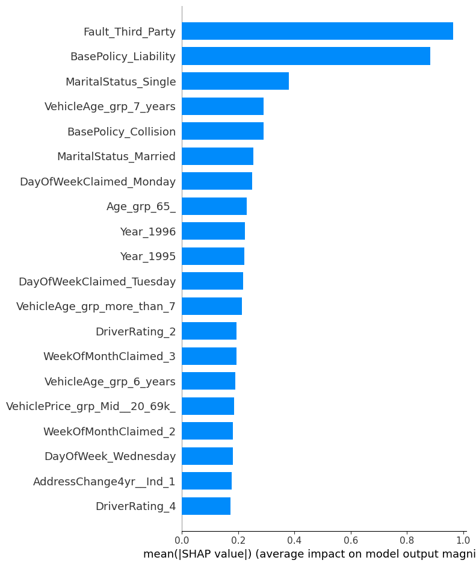

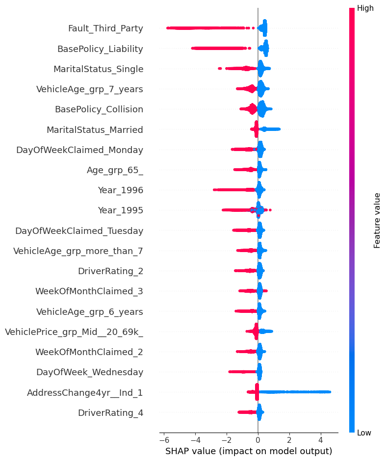

```python
#!pip install shap
import shap

# Initialize SHAP explainer for XGBoost
explainer = shap.TreeExplainer(xgb)
shap_values = explainer.shap_values(X_train_resampled)

# Summary plot (global feature importance)
shap.summary_plot(shap_values, X_train_resampled, plot_type="bar")

# Detailed summary plot (distribution of impact)
shap.summary_plot(shap_values, X_train_resampled)

# Force plot for a single prediction (local explanation)
sample_index = 0
shap.force_plot(explainer.expected_value, shap_values[sample_index], X_train_resampled.iloc[sample_index])
```

### Section 7. Modeling & Tunning

- Modeling on 5-fold CV, model testing and tuning to ensure generalizability
  - Logistic Regression
  - Decision Tree
  - Random Forest
  - Gradient Boosting
  - XGBoost
  - Deep Learning / Deep Neural Networks
- Hyperparameter tuning and grid search to improve model performance

```python
import matplotlib.pyplot as plt
import seaborn as sns
from sklearn.metrics import classification_report, accuracy_score, roc_auc_score, roc_curve, confusion_matrix
from sklearn.model_selection import RandomizedSearchCV, GridSearchCV, StratifiedKFold
from xgboost import XGBClassifier
from sklearn.linear_model import LogisticRegression
from sklearn.ensemble import RandomForestClassifier, GradientBoostingClassifier
from sklearn.tree import DecisionTreeClassifier
import numpy as np
import pandas as pd
import joblib
from tensorflow.keras.models import Sequential
from tensorflow.keras.layers import Dense, Dropout
from tensorflow.keras.optimizers import Adam
from tensorflow.keras.callbacks import EarlyStopping, ReduceLROnPlateau
import keras_tuner as kt

cv = StratifiedKFold(n_splits=5, shuffle=True, random_state=42)

# Traditional Models
models_params = {
    "Logistic Regression": {
        "model": LogisticRegression(max_iter=1000),
        "param_dist": {"C": np.logspace(-3, 2, 10), "solver": ["liblinear", "lbfgs"]}
    },
    "Decision Tree": {
        "model": DecisionTreeClassifier(random_state=42),
        "param_dist": {"max_depth": np.arange(3, 10), "min_samples_split": [2, 5, 10]}
    },
    "Random Forest": {
        "model": RandomForestClassifier(random_state=42),
        "param_dist": {"n_estimators": np.arange(50, 200, 50), "max_depth": np.arange(3, 10)}
    },
    "Gradient Boosting": {
        "model": GradientBoostingClassifier(random_state=42),
        "param_dist": {"n_estimators": np.arange(50, 200, 50), "learning_rate": np.linspace(0.01, 0.3, 5), "max_depth": np.arange(3, 6)}
    },
    "XGBoost": {
        "model": XGBClassifier(random_state=42, use_label_encoder=False, eval_metric='logloss'),
        "param_dist": {
            "n_estimators": np.arange(50, 300, 50),
            "learning_rate": np.linspace(0.01, 0.3, 10),
            "max_depth": np.arange(3, 10)
        }
    }
}

results = {}
confusion_matrices = {}
roc_curves = {}

# Train and tune traditional models
for name, config in models_params.items():
    print(f"\n Tuning {name}...")
    random_search = RandomizedSearchCV(config["model"], config["param_dist"], n_iter=10,
                                       scoring='f1_weighted', cv=cv, random_state=42, n_jobs=-1)
    random_search.fit(X_train_resampled, y_train_resampled)
    best_params = random_search.best_params_
    print(f" Best params for {name}: {best_params}")

    param_grid = {k: [best_params[k]] for k in best_params}
    grid_search = GridSearchCV(config["model"], param_grid, scoring='f1_weighted', cv=cv, n_jobs=-1)
    grid_search.fit(X_train_resampled, y_train_resampled)
    best_model = grid_search.best_estimator_

    preds = best_model.predict(X_test)
    probs = best_model.predict_proba(X_test)[:, 1] if hasattr(best_model, "predict_proba") else None

    report = classification_report(y_test, preds, output_dict=True)
    auc_score = roc_auc_score(y_test, probs) if probs is not None else None

    results[name] = {
        "Accuracy": f"{accuracy_score(y_test, preds)*100:.2f}%",
        "Precision": f"{report['weighted avg']['precision']*100:.2f}%",
        "Recall": f"{report['weighted avg']['recall']*100:.2f}%",
        "F1": f"{report['weighted avg']['f1-score']*100:.2f}%",
        "ROC-AUC": f"{auc_score:.3f}" if auc_score else "N/A"
    }

    confusion_matrices[name] = confusion_matrix(y_test, preds)
    if probs is not None:
        fpr, tpr, _ = roc_curve(y_test, probs)
        roc_curves[name] = (fpr, tpr, auc_score)

    joblib.dump(best_model, f"{name.replace(' ', '_')}_best.pkl")

# Hyperparameter Tuning for DNN using KerasTuner
print("\n Hyperparameter Tuning for Deep Neural Network...")

def build_model(hp):
    model = Sequential()
    model.add(Dense(units=hp.Int('units_layer1', 64, 256, step=64), activation='relu',
                    input_shape=(X_train_resampled.shape[1],)))
    model.add(Dropout(hp.Float('dropout_layer1', 0.2, 0.5, step=0.1)))
    model.add(Dense(units=hp.Int('units_layer2', 32, 128, step=32), activation='relu'))
    model.add(Dropout(hp.Float('dropout_layer2', 0.2, 0.5, step=0.1)))
    model.add(Dense(1, activation='sigmoid'))

    model.compile(optimizer=Adam(learning_rate=hp.Choice('learning_rate', [1e-2, 1e-3, 1e-4])),
                  loss='binary_crossentropy', metrics=['accuracy'])
    return model

tuner = kt.RandomSearch(build_model, objective='val_accuracy', max_trials=10,
                        directory='hyperparam_tuning', project_name='dnn_tuning')

early_stop = EarlyStopping(monitor='val_loss', patience=5, restore_best_weights=True)
lr_schedule = ReduceLROnPlateau(monitor='val_loss', factor=0.5, patience=3)

tuner.search(X_train_resampled, y_train_resampled, epochs=30,
             validation_data=(X_test, y_test), callbacks=[early_stop, lr_schedule])

best_hps = tuner.get_best_hyperparameters(num_trials=1)[0]
print(f"Best hyperparameters: {best_hps.values}")

best_model = tuner.hypermodel.build(best_hps)
history = best_model.fit(X_train_resampled, y_train_resampled,
                          validation_data=(X_test, y_test),
                          epochs=50, batch_size=32,
                          callbacks=[early_stop, lr_schedule])
```

```
 Tuning Logistic Regression...
 Best params for Logistic Regression: {'solver': 'lbfgs', 'C': np.float64(0.5994842503189409)}

 Tuning Decision Tree...
 Best params for Decision Tree: {'min_samples_split': 2, 'max_depth': np.int64(9)}

 Tuning Random Forest...
 Best params for Random Forest: {'n_estimators': np.int64(50), 'max_depth': np.int64(9)}

 Tuning Gradient Boosting...
 Best params for Gradient Boosting: {'n_estimators': np.int64(150), 'max_depth': np.int64(5), 'learning_rate': np.float64(0.22749999999999998)}

 Tuning XGBoost...
 Best params for XGBoost: {'n_estimators': np.int64(200), 'max_depth': np.int64(9), 'learning_rate': np.float64(0.23555555555555557)}

 Hyperparameter Tuning for Deep Neural Network...
Reloading Tuner from hyperparam_tuning\dnn_tuning\tuner0.json
Best hyperparameters: {'units_layer1': 64, 'dropout_layer1': 0.4, 'units_layer2': 32, 'dropout_layer2': 0.4, 'learning_rate': 0.01}
725/725 ━━━━━━━━━━━━━━━━━━━━ 2s 2ms/step - accuracy: 0.9105 - loss: 0.2390 - val_accuracy: 0.9024 - val_loss: 0.2639 - learning_rate: 0.0100
725/725 ━━━━━━━━━━━━━━━━━━━━ 1s 1ms/step - accuracy: 0.9353 - loss: 0.1870 - val_accuracy: 0.9189 - val_loss: 0.2394 - learning_rate: 0.0100
725/725 ━━━━━━━━━━━━━━━━━━━━ 1s 2ms/step - accuracy: 0.9416 - loss: 0.1729 - val_accuracy: 0.9193 - val_loss: 0.2350 - learning_rate: 0.0100
725/725 ━━━━━━━━━━━━━━━━━━━━ 1s 2ms/step - accuracy: 0.9476 - loss: 0.1572 - val_accuracy: 0.9235 - val_loss: 0.2256 - learning_rate: 0.0100
725/725 ━━━━━━━━━━━━━━━━━━━━ 1s 2ms/step - accuracy: 0.9475 - loss: 0.1541 - val_accuracy: 0.9339 - val_loss: 0.2027 - learning_rate: 0.0100
725/725 ━━━━━━━━━━━━━━━━━━━━ 1s 1ms/step - accuracy: 0.9474 - loss: 0.1507 - val_accuracy: 0.9209 - val_loss: 0.2385 - learning_rate: 0.0100
725/725 ━━━━━━━━━━━━━━━━━━━━ 1s 1ms/step - accuracy: 0.9496 - loss: 0.1506 - val_accuracy: 0.9209 - val_loss: 0.2276 - learning_rate: 0.0100
725/725 ━━━━━━━━━━━━━━━━━━━━ 1s 1ms/step - accuracy: 0.9514 - loss: 0.1404 - val_accuracy: 0.9186 - val_loss: 0.2350 - learning_rate: 0.0100
725/725 ━━━━━━━━━━━━━━━━━━━━ 1s 1ms/step - accuracy: 0.9584 - loss: 0.1235 - val_accuracy: 0.9241 - val_loss: 0.2276 - learning_rate: 0.0050
725/725 ━━━━━━━━━━━━━━━━━━━━ 1s 1ms/step - accuracy: 0.9590 - loss: 0.1194 - val_accuracy: 0.9277 - val_loss: 0.2288 - learning_rate: 0.0050
```

### Section 8. Model Evaluation

```
97/97 ━━━━━━━━━━━━━━━━━━━━ 0s 1ms/step
97/97 ━━━━━━━━━━━━━━━━━━━━ 0s 729us/step

 Summary of All Models:

                          Accuracy Precision  Recall      F1 ROC-AUC
Logistic Regression         90.01%    89.65%  90.01%  89.83%   0.771
Decision Tree               77.20%    92.24%  77.20%  82.87%   0.799
Random Forest               76.95%    92.48%  76.95%  82.72%   0.812
Gradient Boosting           91.21%    90.06%  91.21%  90.61%   0.812
XGBoost                     91.89%    90.00%  91.89%  90.86%   0.824
Tuned Deep Neural Network   93.39%    89.65%  93.39%  91.11%   0.803
```

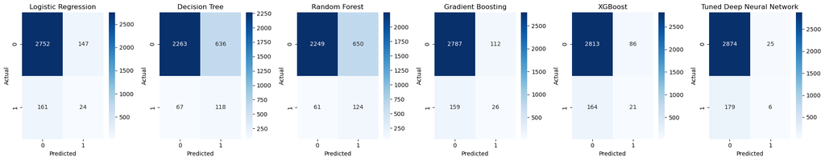

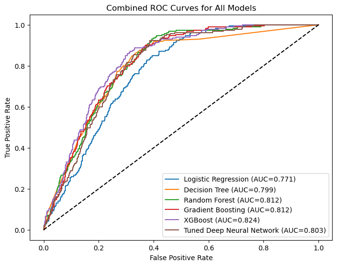

```python
# Evaluate tuned DNN
dnn_preds = (best_model.predict(X_test) > 0.5).astype("int32")
dnn_probs = best_model.predict(X_test).flatten()
report = classification_report(y_test, dnn_preds, output_dict=True)
auc_score = roc_auc_score(y_test, dnn_probs)

results["Tuned Deep Neural Network"] = {
    "Accuracy": f"{report['accuracy']*100:.2f}%",
    "Precision": f"{report['weighted avg']['precision']*100:.2f}%",
    "Recall": f"{report['weighted avg']['recall']*100:.2f}%",
    "F1": f"{report['weighted avg']['f1-score']*100:.2f}%",
    "ROC-AUC": f"{auc_score:.3f}"
}

confusion_matrices["Tuned Deep Neural Network"] = confusion_matrix(y_test, dnn_preds)
fpr, tpr, _ = roc_curve(y_test, dnn_probs)
roc_curves["Tuned Deep Neural Network"] = (fpr, tpr, auc_score)

# Summary Table
summary_df = pd.DataFrame(results).T
print("\n Summary of All Models:\n")
print(summary_df)

# Plot Confusion Matrices
fig, axes = plt.subplots(1, len(confusion_matrices), figsize=(20, 4))
for ax, (name, cm) in zip(axes, confusion_matrices.items()):
    sns.heatmap(cm, annot=True, fmt='d', cmap='Blues', ax=ax)
    ax.set_title(name)
    ax.set_xlabel("Predicted")
    ax.set_ylabel("Actual")
plt.tight_layout()
plt.show()

# Combined ROC Curve
plt.figure(figsize=(8, 6))
for name, (fpr, tpr, auc_score) in roc_curves.items():
    plt.plot(fpr, tpr, label=f"{name} (AUC={auc_score:.3f})")
plt.plot([0, 1], [0, 1], 'k--')
plt.xlabel("False Positive Rate")
plt.ylabel("True Positive Rate")
plt.title("Combined ROC Curves for All Models")
plt.legend()
plt.show()
```

### Section 9. Model Deployment and Monitoring

Given the nature of the capstone project using open source data, the Fraud Detection moldeing wouldn't be able to deploy. However, I would like to share some guidance and best practices from past experience:

1. Importance of Model Deployment
- Deployment moves models from development into production systems for real-time predictions to solve business problems.
- Before full implementation:
  - Model Pilot: Test in a controlled environment to validate performance.
  - Champion-Challenger Approach: Compare new model against existing one (if there is) to justify deployment.
2. Infrastructure Considerations
- Advanced ML models (Random Forest, Gradient Boosting) require special IT capabilities:
  - Cloud platforms: AWS, Azure, Google Cloud
  - Big Data frameworks: Spark, Hadoop
- Cost-Benefit Analysis: Balance improved performance vs. implementation cost.
3. Deployment Best Practices
- Containerization: Use Docker for reproducible environments.
- Orchestration: Use Kubernetes for auto-scaling and load balancing.
- Model Serving: Tools like TensorFlow Serving, TorchServe, or Triton.
- Version Control: Track model versions, data, and configurations for rollback.
- Deployment Strategies:
  - Canary Deployment: Gradual rollout to a subset of users.
  - Shadow Deployment: Run new model alongside old one for comparison.
  - A/B Testing: Compare multiple models in production.
4. Monitoring Essentials: Monitoring is continuous and mandatory:
- Performance Metrics: Accuracy, Precision, Recall, F1, ROC-AUC.
- Data Drift Detection: Identify shifts in input data distribution.
- Concept Drift: Detect changes in feature-target relationships.
- Latency & Throughput: Ensure real-time prediction capability.
- Alerting: Automated alerts for anomalies or degradation.
- Audit & Compliance: Maintain logs for regulatory requirements (critical for fraud detection).
5. Continuous Improvement
- Automated Retraining: Trigger when performance drops or data drift occurs.
- Feedback Loops: Include human-in-the-loop for fraud alerts.
- Explainability: Use SHAP or LIME for transparency in regulated environments.

This structured approach ensures robust deployment, cost efficiency, compliance, and sustained model performance.

### Key Fraud Detection Insights

**1. Recall is King in Fraud Detection**

**2. Precision Trade-off**

**3. ROC-AUC Analysis**

- XGBoost (0.824) and Gradient Boosting & Random Forest (0.812) lead in ROC-AUC, meaning they rank transactions well by fraud likelihood.
- DNN’s ROC-AUC (0.803) is slightly lower, so probability calibration may need improvement for threshold tuning.